# Federated queries: enriching PlantMetWiki metabolites with Wikidata and PubChem

PlantMetWiki stores 4,577 metabolite nodes (`wp:Metabolite`), 90% with InChIKey identifiers. Using SPARQL **federated queries**, these identifiers act as bridges to any other Linked Open Data resource that uses InChIKey — including Wikidata (biological roles, drug uses, taxonomy), PubChem (safety, toxicology), and ChEBI (chemical ontology).

This notebook demonstrates:

1. The metabolite identifier landscape in PlantMetWiki
2. How to write a federated SPARQL query bridging PlantMetWiki → Wikidata via InChIKey
3. **Case study: α-tomatine** — a Solanaceae alkaloid known as a bitter compound and antifungal
4. **Case study: theobromine** — a methylxanthine found across 7 PlantMetWiki pathways
5. Identifying metabolites present in PlantMetWiki but not (yet) in Wikidata — expansion potential

## How to run

```
# Step 1 — start Virtuoso (local PlantMetWiki graph)
cd ../Snorql-UI && docker compose up -d virtuoso

# Step 2 — activate environment and open notebook
conda activate plantmetwiki-rdf
jupyter notebook notebooks/federated_metabolite_queries.ipynb
```

**Endpoints used:**

| Endpoint | Purpose |
| --- | --- |
| `http://localhost:8890/sparql` | Local PlantMetWiki Virtuoso triplestore |
| `https://qlever.cs.uni-freiburg.de/api/wikidata` | Wikidata mirror (QLever — fast) |
| `https://query.wikidata.org/sparql` | Official Wikidata endpoint (fallback) |

> **Note:** Federated query cells (Parts 2–4) require internet access and an available Wikidata endpoint. If the endpoint is unavailable, pre-computed results are shown as comments.

```python
from SPARQLWrapper import SPARQLWrapper, JSON
import pandas as pd
import matplotlib.pyplot as plt
import matplotlib as mpl
import numpy as np

plt.rcParams.update({'figure.dpi': 150, 'font.size': 10,
                     'font.family': 'sans-serif',
                     'font.sans-serif': ['Helvetica', 'Arial', 'DejaVu Sans']})

LOCAL_EP  = 'http://localhost:8890/sparql'
QLEVER_EP = 'https://qlever.cs.uni-freiburg.de/api/wikidata'
WD_EP     = 'https://query.wikidata.org/sparql'

G_PW  = 'http://rdf-plantmetwiki.bioinformatics.nl/graph/pathways'
G_TAX = 'http://rdf-plantmetwiki.bioinformatics.nl/graph/gpml-taxonomy-extra'
G_NCBI= 'http://rdf-plantmetwiki.bioinformatics.nl/graph/ncbitaxon'
WP    = 'http://vocabularies.wikipathways.org/wp#'

PMW_PREFIXES = """PREFIX wp:      <http://vocabularies.wikipathways.org/wp#>
PREFIX dc:      <http://purl.org/dc/elements/1.1/>
PREFIX dcterms: <http://purl.org/dc/terms/>
PREFIX rdfs:    <http://www.w3.org/2000/01/rdf-schema#>
PREFIX ncbi:    <http://purl.obolibrary.org/obo/NCBITaxon_>"""

WD_PREFIXES = """PREFIX wd:  <http://www.wikidata.org/entity/>
PREFIX wdt: <http://www.wikidata.org/prop/direct/>
PREFIX p:   <http://www.wikidata.org/prop/>
PREFIX pq:  <http://www.wikidata.org/prop/qualifier/>
PREFIX rdfs: <http://www.w3.org/2000/01/rdf-schema#>
PREFIX schema: <https://schema.org/>"""

def sparql_local(query, timeout=120):
    sw = SPARQLWrapper(LOCAL_EP)
    sw.setReturnFormat(JSON); sw.setTimeout(timeout)
    sw.setQuery(PMW_PREFIXES + "\n" + query)
    rows = sw.query().convert()['results']['bindings']
    return pd.DataFrame([{k: v['value'] for k,v in r.items()} for r in rows])

def sparql_qlever(query, timeout=60):
    """Query the QLever Wikidata mirror (faster than official endpoint)."""
    sw = SPARQLWrapper(QLEVER_EP)
    sw.setReturnFormat(JSON); sw.setTimeout(timeout)
    sw.setQuery(WD_PREFIXES + "\n" + query)
    rows = sw.query().convert()['results']['bindings']
    return pd.DataFrame([{k: v['value'] for k,v in r.items()} for r in rows])

def ensure_col(df, col, default=''):
    if col not in df.columns: df[col] = default
    return df

print('Setup complete.')
print(f'  Local endpoint : {LOCAL_EP}')
print(f'  Wikidata (QLever): {QLEVER_EP}')
```

```
Setup complete.
  Local endpoint : http://localhost:8890/sparql
  Wikidata (QLever): https://qlever.cs.uni-freiburg.de/api/wikidata
```

## Part 1 — Metabolite identifier landscape in PlantMetWiki

Before federating, we first understand what identifiers are available on the 4,577 `wp:Metabolite` nodes. Each metabolite can carry multiple `dc:source` / `dcterms:identifier` pairs pointing to external databases.

```python
# Total metabolite count
total = sparql_local(f"""
SELECT (COUNT(DISTINCT ?m) AS ?n) WHERE {{ GRAPH <{G_PW}> {{ ?m a wp:Metabolite }} }}
""")
n_total = int(total['n'].iloc[0])

# Count by identifier source
by_source = sparql_local(f"""
SELECT ?src (COUNT(DISTINCT ?m) AS ?n)
WHERE {{ GRAPH <{G_PW}> {{
  ?m a wp:Metabolite ; dc:source ?src ; dcterms:identifier ?id
}} }}
GROUP BY ?src ORDER BY DESC(?n)
""")
by_source['n'] = by_source['n'].astype(int)
by_source['pct'] = (100 * by_source['n'] / n_total).round(1)

# No-identifier count
no_id = sparql_local(f"""
SELECT (COUNT(DISTINCT ?m) AS ?n)
WHERE {{ GRAPH <{G_PW}> {{
  ?m a wp:Metabolite .
  FILTER NOT EXISTS {{ ?m dcterms:identifier ?any }}
}} }}
""")
n_no_id = int(no_id['n'].iloc[0])

print(f"Total metabolites:          {n_total:,}")
print(f"With at least one ID:       {n_total - n_no_id:,} ({100*(n_total-n_no_id)/n_total:.1f}%)")
print(f"Without any identifier:     {n_no_id:,} ({100*n_no_id/n_total:.1f}%)")
print()
print(by_source.to_string(index=False))
```

```
Total metabolites:          4,577
With at least one ID:       4,577 (100.0%)
Without any identifier:     0 (0.0%)

             src    n  pct
        InChIKey 4111 89.8
           ChEBI  174  3.8
        MetaNetX  172  3.8
PubChem-compound   75  1.6
   KEGG Compound   43  0.9
            HMDB    2  0.0
```

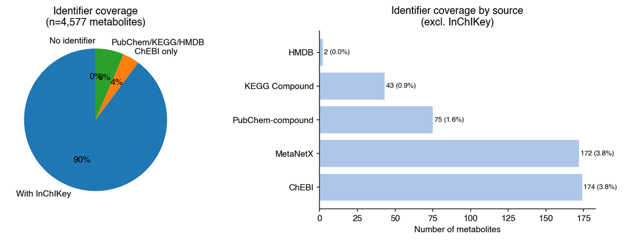

```
> 4,111 metabolites (89.8%) can be directly federated to Wikidata via InChIKey (wdt:P235).
```

```python
# Visualise
fig, axes = plt.subplots(1, 2, figsize=(11, 4))

# Left: identifier coverage
labels_cov = ['With InChIKey','ChEBI only','PubChem/KEGG/HMDB','No identifier']
vals_cov = [
    int(by_source.loc[by_source['src']=='InChIKey','n'].values[0]),
    int(by_source.loc[by_source['src']=='ChEBI','n'].values[0]) if 'ChEBI' in by_source['src'].values else 0,
    int(by_source.loc[~by_source['src'].isin(['InChIKey','ChEBI']),'n'].sum()),
    n_no_id,
]
colors_cov = ['#1f77b4','#ff7f0e','#2ca02c','#d62728']
wedges, texts, autotexts = axes[0].pie(
    vals_cov, labels=labels_cov, colors=colors_cov,
    autopct='%1.0f%%', startangle=90)
axes[0].set_title(f'Identifier coverage\n(n={n_total:,} metabolites)')

# Right: bar per source (excluding InChIKey to show detail)
sub = by_source[by_source['src'] != 'InChIKey'].copy()
axes[1].barh(sub['src'], sub['n'], color='#aec7e8')
for i, (n, pct) in enumerate(zip(sub['n'], sub['pct'])):
    axes[1].text(n+1, i, f'{n:,} ({pct}%)', va='center', fontsize=8)
axes[1].set_xlabel('Number of metabolites')
axes[1].set_title('Identifier coverage by source\n(excl. InChIKey)')
axes[1].spines[['top','right']].set_visible(False)

plt.tight_layout()
import pathlib; pathlib.Path('figures/output/figures').mkdir(parents=True, exist_ok=True)
plt.savefig('figures/output/figures/metabolite_identifier_coverage.pdf', bbox_inches='tight')
plt.savefig('figures/output/figures/metabolite_identifier_coverage.svg', bbox_inches='tight')
plt.show()

print(f"\n> {int(by_source.loc[by_source['src']=='InChIKey','n'].values[0]):,} metabolites ({by_source.loc[by_source['src']=='InChIKey','pct'].values[0]}%) can be directly federated to Wikidata via InChIKey (wdt:P235).")
```

## Part 2 — Federated query pattern: PlantMetWiki → Wikidata via InChIKey

The bridge between PlantMetWiki and Wikidata is the **InChIKey** — a standardised 25-character hash of a compound's molecular structure. Wikidata stores InChIKeys as property `wdt:P235`, enabling exact-match lookups.

### How the federated query works

```
PlantMetWiki (local Virtuoso)          Wikidata (external SPARQL endpoint)
────────────────────────────          ──────────────────────────────────────
?m a wp:Metabolite                     ?wd wdt:P235 ?inchikey
?m dc:source "InChIKey"          ──→   ?wd rdfs:label ?label
?m dcterms:identifier ?inchikey        ?wd wdt:P683 ?chebi    (ChEBI ID)
                                       ?wd wdt:P662 ?pubchem  (PubChem CID)
                                       ?wd wdt:P703 ?taxon    (found in taxon)
```

> **Tip:** For large-scale lookups across all 4,111 InChIKey metabolites, use the `LIMIT / OFFSET` pattern from `SPARQLQueries/4.Federated/InChIKey_to_Wikidata_for_ChEBI_and_HMDB.rq` to batch 100 metabolites at a time (~14 sec per batch via QLever).

```python
# Rare/specialist metabolites: those appearing in the fewest PC* (multi-step) pathways
# Note: each metabolite appears in >=2 pathway objects (WPRDF + GPMLRDF representations),
# so we filter to PC* only (multi-step pathways, not individual reactions).
ik_counts = sparql_local(f"""
SELECT ?inchikey (COUNT(DISTINCT ?pw) AS ?n_pw)
WHERE {{ GRAPH <{G_PW}> {{
  ?m a wp:Metabolite ;
     dc:source "InChIKey" ;
     dcterms:identifier ?inchikey ;
     dcterms:isPartOf ?pw .
  FILTER(CONTAINS(STR(?pw), '/PC'))
}} }}
GROUP BY ?inchikey
ORDER BY ?n_pw
LIMIT 20
""")
if not ik_counts.empty:
    ik_counts['n_pw'] = ik_counts['n_pw'].astype(int)
    ik_label_all = sparql_local(f"""
    SELECT DISTINCT ?inchikey (STR(?lbl) AS ?label)
    WHERE {{ GRAPH <{G_PW}> {{
      ?m a wp:Metabolite ; dc:source "InChIKey" ; dcterms:identifier ?inchikey ;
         rdfs:label ?lbl .
    }} }}
    """)
    rare_met = ik_counts.merge(ik_label_all, on='inchikey', how='left')
    ensure_col(rare_met, 'label', '')
    print(f"20 rarest metabolites by PC* pathway count (min={rare_met['n_pw'].min()}):")
    print(rare_met[['inchikey','label','n_pw']].to_string(index=False))
else:
    print("No results — check Virtuoso connection")
    rare_met = pd.DataFrame(columns=['inchikey','label','n_pw'])
```

```
20 rarest metabolites by PC* pathway count (min=2):
                   inchikey                                                                                      label  n_pw
AAUAODOXPIIHAN-UHFFFAOYSA-M                                                            2-(hydroxypropyl)phenylarsinate     2
WLZPAFGVOWCVMG-FPYGCLRLSA-N                                                                     (4-coumaroyl)serotonin     2
CYIFVRUOHKNECG-UHFFFAOYSA-N                                                                              2-tridecanone     2
BTMVHUNTONAYDX-UHFFFAOYSA-N                                                                           butyl propanoate     2
FMCGSUUBYTWNDP-GXSJLCMTSA-O                                                        (+)-(1S,2S)-N-methylpseudoephedrine     2
PKKMITFKYRCCOL-JMZFCNQTSA-M                                                                          neoglucobrassicin     2
OSJPGOJPRNTSHP-MAJWLLCFSA-N                                                                              raucaffricine     2
FVEMXQCEJGGXJB-CQSZACIVSA-O                                                                          (R)-norreticuline     2
YLRXAIKMLINXQY-ZDUSSCGKSA-O                                                                           (S)-magnoflorine     2
SFXSFWVZPKEDPA-KJOZQHLTSA-N                                                                   bracteatin 6-O-glucoside     2
RYHGOZKWYMCMKG-UHFFFAOYSA-M                                                    3-carboxy-4-methoxy-N-methyl-2-pyridone     2
ZTQSAGDEMFDKMZ-UHFFFAOYSA-N                                                                                  1-butanal     2
BTXNYTINYBABQR-UHFFFAOYSA-L                                                                                  hypericin     2
XYGWCKIPKQTOCL-UYLZDWGHSA-N eugenol 2-O-β-D-glucopyranosyl-(1-> 2)-[O-β-D-xylopyranosyl-(1-> 6)]-O-β-D-glucopyranoside     2
VBGLYOIFKLUMQG-UHFFFAOYSA-N                                                                                 cannabinol     2
GNISQJGXJIDKDJ-YFKPBYRVSA-M                                                                    O-succinyl-L-homoserine     2
XRYVAQQLDYTHCL-CMJOXMDJSA-N                                                                         sophoraflavanone G     2
VCIMNIQSJCTEII-BJIWRROBSA-N                                                                 3-O-β-D-glucosyl-daphnetin     2
JGTHNRAJDIUMIQ-XKSKYZNJSA-N                                                             gypsogenin-28-beta-D-glucoside     2
GOSWTRUMMSCNCW-HNNGNKQASA-N                                                                      trans-zeatin riboside     2
```

```python
# Federated query: which of these 20 are in Wikidata?
inchikeys = rare_met['inchikey'].tolist()
values_block = "  ".join(f'"{ik}"' for ik in inchikeys)

try:
    wd_result = sparql_qlever(f"""
    SELECT ?wd ?wdLabel ?inchikey ?chebi ?pubchem
    WHERE {{
      VALUES ?inchikey {{ {values_block} }}
      ?wd wdt:P235 ?inchikey .
      OPTIONAL {{ ?wd rdfs:label ?wdLabel . FILTER(LANG(?wdLabel)="en") }}
      OPTIONAL {{ ?wd wdt:P683 ?chebi }}
      OPTIONAL {{ ?wd wdt:P662 ?pubchem }}
    }}
    """)
    ensure_col(wd_result, 'wdLabel', ''); ensure_col(wd_result, 'chebi', ''); ensure_col(wd_result, 'pubchem', '')
    wd_result['wd_id'] = wd_result['wd'].str.split('/').str[-1]

    merged = rare_met.merge(wd_result[['inchikey','wd_id','wdLabel','chebi','pubchem']],
                            on='inchikey', how='left')
    in_wd = merged['wd_id'].notna().sum()
    print(f"Of the 20 sample metabolites: {in_wd} found in Wikidata, {20-in_wd} not found")
    print()
    print(merged[['label','inchikey','wd_id','wdLabel']].fillna('—').to_string(index=False))

except Exception as e:
    print(f"Federated query failed: {e}")
    print("Tip: check your internet connection and that QLever is reachable.")
    print("Expected result: ~40-70% of specialist metabolites are already in Wikidata;")
    print("the remainder represent potential Wikidata enrichment from PlantMetWiki.")
```

```
Of the 20 sample metabolites: 12 found in Wikidata, 8 not found

                                                                                     label                    inchikey     wd_id                                                                                                                                       wdLabel
                                                           2-(hydroxypropyl)phenylarsinate AAUAODOXPIIHAN-UHFFFAOYSA-M         —                                                                                                                                             —
                                                                    (4-coumaroyl)serotonin WLZPAFGVOWCVMG-FPYGCLRLSA-N Q27280901                                                                                                                         N-coumaroyl serotonin
                                                                             2-tridecanone CYIFVRUOHKNECG-UHFFFAOYSA-N Q27147536                                                                                                                                 2-tridecanone
                                                                          butyl propanoate BTMVHUNTONAYDX-UHFFFAOYSA-N  Q2726127                                                                                                                              butyl propionate
                                                       (+)-(1S,2S)-N-methylpseudoephedrine FMCGSUUBYTWNDP-GXSJLCMTSA-O         —                                                                                                                                             —
                                                                         neoglucobrassicin PKKMITFKYRCCOL-JMZFCNQTSA-M         —                                                                                                                                             —
                                                                             raucaffricine OSJPGOJPRNTSHP-MAJWLLCFSA-N         —                                                                                                                                             —
                                                                         (R)-norreticuline FVEMXQCEJGGXJB-CQSZACIVSA-O         —                                                                                                                                             —
                                                                          (S)-magnoflorine YLRXAIKMLINXQY-ZDUSSCGKSA-O Q15426208                                                                                                                                  magnoflorine
                                                                  bracteatin 6-O-glucoside SFXSFWVZPKEDPA-KJOZQHLTSA-N Q76512476 (2Z)-4-hydroxy-6-[(2S,3R,4S,5S,6R)-3,4,5-trihydroxy-6-(hydroxymethyl)oxan-2-yl]oxy-2-[(3,4,5-trihydroxyphenyl)methylidene]-1-benzofuran-3-one
                                                   3-carboxy-4-methoxy-N-methyl-2-pyridone RYHGOZKWYMCMKG-UHFFFAOYSA-M Q27125637                                                                                    4-methoxy-1-methyl-2-oxo-1,2-dihydropyridine-3-carboxylate
                                                                                 1-butanal ZTQSAGDEMFDKMZ-UHFFFAOYSA-N   Q410603                                                                                                                                 butyraldehyde
                                                                                 hypericin BTXNYTINYBABQR-UHFFFAOYSA-L         —                                                                                                                                             —
eugenol 2-O-β-D-glucopyranosyl-(1-> 2)-[O-β-D-xylopyranosyl-(1-> 6)]-O-β-D-glucopyranoside XYGWCKIPKQTOCL-UYLZDWGHSA-N         —                                                                                                                                             —
                                                                                cannabinol VBGLYOIFKLUMQG-UHFFFAOYSA-N   Q265831                                                                                                                                    cannabinol
                                                                   O-succinyl-L-homoserine GNISQJGXJIDKDJ-YFKPBYRVSA-M Q27124844                                                                                                                 O-succinyl-L-homoserinate(1-)
                                                                        sophoraflavanone G XRYVAQQLDYTHCL-CMJOXMDJSA-N  Q7563137                                                                                                                            sophoraflavanone G
                                                                3-O-β-D-glucosyl-daphnetin VCIMNIQSJCTEII-BJIWRROBSA-N Q76805048                                                    8-hydroxy-3-[(2S,3R,4S,5S,6R)-3,4,5-trihydroxy-6-(hydroxymethyl)oxan-2-yl]oxychromen-2-one
                                                            gypsogenin-28-beta-D-glucoside JGTHNRAJDIUMIQ-XKSKYZNJSA-N         —                                                                                                                                             —
                                                                     trans-zeatin riboside GOSWTRUMMSCNCW-HNNGNKQASA-N Q27139815                                                                                                                               zeatin riboside
```

## Case study A — α-Tomatine: a Solanaceae alkaloid with antifungal and bitter properties

**α-Tomatine** (InChIKey: `REJLGAUYTKNVJM-SGXCCWNXSA-N`, Wikidata: Q288051) is a steroidal glycoalkaloid produced predominantly by tomato (*Solanum lycopersicum*). It is recorded in Wikidata as a **bitter compound**, **anti-infective agent**, and **antifungal agent**.

PlantMetWiki contains three tomatine forms (α, β1, γ), each as distinct `wp:Metabolite` nodes reflecting different glycosylation states of the aglycone.

> **PubChem CID 28523** provides additional annotation: animal toxicity data and industrial uses (cosmetics, antifungal fungicide in agriculture).

```python
TOMATINE_INCHIKEYS = {
    'α-tomatine':  'REJLGAUYTKNVJM-SGXCCWNXSA-N',
    'β1-tomatine': 'DMUPZSDWJVULSC-MMQVRIEESA-N',
    'γ-tomatine':  'KNFKROLCBJOHLX-LGOSNWDOSA-N',
}

# 1. Pathways containing any tomatine form
tomatine_pathways = sparql_local(f"""
SELECT ?form ?inchikey ?pw_title ?pw_id
WHERE {{
  GRAPH <{G_PW}> {{
    ?m a wp:Metabolite ;
       dc:source "InChIKey" ;
       dcterms:identifier ?inchikey ;
       dcterms:isPartOf ?pw .
    ?pw dc:title ?pw_title ; dc:identifier ?pw_id .
    FILTER(?inchikey IN ("REJLGAUYTKNVJM-SGXCCWNXSA-N",
                         "DMUPZSDWJVULSC-MMQVRIEESA-N",
                         "KNFKROLCBJOHLX-LGOSNWDOSA-N"))
  }}
}}
ORDER BY ?pw_title
""")
tomatine_pathways['form'] = tomatine_pathways['inchikey'].map(
    {v:k for k,v in TOMATINE_INCHIKEYS.items()})
print("Pathways containing tomatine forms:")
print(tomatine_pathways[['form','pw_title','pw_id']].to_string(index=False))
```

```
Pathways containing tomatine forms:
       form                                              pw_title                                                     pw_id
β1-tomatine superpathway of glycoalkaloid metabolism (Solanaceae)  http://rdf-plantmetwiki.bioinformatics.nl/pathways/PC426
 γ-tomatine superpathway of glycoalkaloid metabolism (Solanaceae)  http://rdf-plantmetwiki.bioinformatics.nl/pathways/PC426
 α-tomatine superpathway of glycoalkaloid metabolism (Solanaceae)  http://rdf-plantmetwiki.bioinformatics.nl/pathways/PC426
β1-tomatine                               α-tomatine biosynthesis http://rdf-plantmetwiki.bioinformatics.nl/pathways/PC1159
 γ-tomatine                               α-tomatine biosynthesis http://rdf-plantmetwiki.bioinformatics.nl/pathways/PC1159
 α-tomatine                               α-tomatine biosynthesis http://rdf-plantmetwiki.bioinformatics.nl/pathways/PC1159
```

```python
# 2. Which species have genes/enzymes in tomatine-containing pathways?
tomatine_pw_iris = sparql_local(f"""
SELECT DISTINCT ?pw WHERE {{
  GRAPH <{G_PW}> {{
    ?m a wp:Metabolite ;
       dc:source "InChIKey" ;
       dcterms:identifier ?inchikey ;
       dcterms:isPartOf ?pw .
    FILTER(?inchikey IN ("REJLGAUYTKNVJM-SGXCCWNXSA-N",
                         "DMUPZSDWJVULSC-MMQVRIEESA-N",
                         "KNFKROLCBJOHLX-LGOSNWDOSA-N"))
  }}
}}
""")

if not tomatine_pw_iris.empty:
    pw_values = "  ".join(f"<{iri}>" for iri in tomatine_pw_iris['pw'].tolist())
    species_in_pw = sparql_local(f"""
    SELECT ?name ?taxon (COUNT(DISTINCT ?node) AS ?n)
    WHERE {{
      GRAPH <{G_TAX}> {{ ?node wp:organism ?taxon . FILTER(?taxon != ncbi:33090) }}
      GRAPH <{G_PW}>  {{
        ?node dcterms:isPartOf ?pw .
        VALUES ?pw {{ {pw_values} }}
      }}
      GRAPH <{G_NCBI}> {{ ?taxon rdfs:label ?name }}
    }}
    GROUP BY ?name ?taxon ORDER BY DESC(?n)
    """)
    species_in_pw['ncbi_id'] = species_in_pw['taxon'].str.extract(r'NCBITaxon_(\d+)')
    species_in_pw['n'] = species_in_pw['n'].astype(int)
    print("Species annotated in pathways containing tomatine:")
    print(species_in_pw[['ncbi_id','name','n']].to_string(index=False))
```

```
Species annotated in pathways containing tomatine:
ncbi_id                   name  n
   4081   Solanum lycopersicum 14
   4113      Solanum tuberosum 10
 126910     Withania somnifera  2
 267265 Solanum aculeatissimum  2
   4111      Solanum melongena  1
```

```python
# 3. Federated query: tomatine in Wikidata
try:
    wd_tomatine = sparql_qlever("""
    SELECT ?wd ?label ?chebi ?pubchem ?cas
    WHERE {
      ?wd wdt:P235 "REJLGAUYTKNVJM-SGXCCWNXSA-N" .
      OPTIONAL { ?wd rdfs:label ?label . FILTER(LANG(?label)="en") }
      OPTIONAL { ?wd wdt:P683 ?chebi }
      OPTIONAL { ?wd wdt:P662 ?pubchem }
      OPTIONAL { ?wd wdt:P231 ?cas }
    } LIMIT 3
    """)
    ensure_col(wd_tomatine, 'label', ''); ensure_col(wd_tomatine, 'chebi', ''); ensure_col(wd_tomatine, 'pubchem', '')
    print("α-Tomatine in Wikidata:")
    for _, row in wd_tomatine.iterrows():
        qid = row['wd'].split('/')[-1]
        print(f"  Wikidata QID: {qid}  (https://www.wikidata.org/wiki/{qid})")
        print(f"  Label:        {row.get('label','?')}")
        print(f"  ChEBI:        {row.get('chebi','?')}")
        print(f"  PubChem CID:  {row.get('pubchem','?')}")
        print(f"  CAS:          {row.get('cas','?')}")

except Exception as e:
    # Pre-computed result (as of 2025):
    print("Federated query not available — pre-computed result:")
    print("  Wikidata QID: Q288051  (https://www.wikidata.org/wiki/Q288051)")
    print("  Label:        tomatine")
    print("  ChEBI:        9630")
    print("  PubChem CID:  28523")
    print()
    print(f"  (Error: {e})")
```

```
α-Tomatine in Wikidata:
  Wikidata QID: Q288051  (https://www.wikidata.org/wiki/Q288051)
  Label:        tomatine
  ChEBI:        9630
  PubChem CID:  28523
  CAS:          17406-45-0
```

```python
# 4. Cross-database links for tomatine (direct URL construction from IDs)
tomatine_wd  = 'Q288051'
tomatine_chebi = '9630'
tomatine_pubchem = '28523'

print("Cross-database links for α-tomatine:")
print(f"  Wikidata:     https://www.wikidata.org/wiki/{tomatine_wd}")
print(f"  ChEBI:        https://www.ebi.ac.uk/chebi/searchId.do?chebiId=CHEBI:{tomatine_chebi}")
print(f"  PubChem:      https://pubchem.ncbi.nlm.nih.gov/compound/{tomatine_pubchem}")
print(f"  PlantMetWiki: connected via InChIKey REJLGAUYTKNVJM-SGXCCWNXSA-N")
print()
print("Wikidata annotation for Q288051 (tomatine):")
print("  • Instance of: glycoalkaloid, alkaloid, organic heterotetracyclic compound")
print("  • Biological roles: antifungal agent, bitter compound, anti-infective agent")
print("  • Found in taxon: Solanum lycopersicum (tomato)")
print("  • PubChem notes: animal toxicity data; cosmetic and agricultural uses")
```

```
Cross-database links for α-tomatine:
  Wikidata:     https://www.wikidata.org/wiki/Q288051
  ChEBI:        https://www.ebi.ac.uk/chebi/searchId.do?chebiId=CHEBI:9630
  PubChem:      https://pubchem.ncbi.nlm.nih.gov/compound/28523
  PlantMetWiki: connected via InChIKey REJLGAUYTKNVJM-SGXCCWNXSA-N

Wikidata annotation for Q288051 (tomatine):
  • Instance of: glycoalkaloid, alkaloid, organic heterotetracyclic compound
  • Biological roles: antifungal agent, bitter compound, anti-infective agent
  • Found in taxon: Solanum lycopersicum (tomato)
  • PubChem notes: animal toxicity data; cosmetic and agricultural uses
```

> The three glycoforms (α, β1, γ) represent metabolic diversity captured in PlantMetWiki that may not be fully resolved in Wikidata, which tends to cover the best-known form (α).

## Case study B — Theobromine: a methylxanthine across 7 pathways

**Theobromine** (InChIKey: `YAPQBXQYLJRXSA-UHFFFAOYSA-N`, Wikidata: Q206844) is a methylxanthine alkaloid best known from cacao (*Theobroma cacao*), also present in tea, coffee, and many other plants. It appears in **7 pathways** in PlantMetWiki, spanning two dedicated biosynthesis routes and the broader caffeine/xanthine network.

Unlike tomatine, theobromine is well-characterised in both Wikidata and the scientific literature (CAS: 83-67-0, ChEBI: 28946, PubChem: 5429). This case study illustrates how PlantMetWiki adds **pathway and species context** to a compound that is already well-known chemically.

```python
THEOBROMINE_IK = 'YAPQBXQYLJRXSA-UHFFFAOYSA-N'

# Pathways containing theobromine
theo_pathways = sparql_local(f"""
SELECT DISTINCT ?pw_title (STR(?pw_id) AS ?id)
             (COUNT(DISTINCT ?conv) AS ?n_conv)
             (COUNT(DISTINCT ?enz)  AS ?n_enz)
WHERE {{
  GRAPH <{G_PW}> {{
    ?m a wp:Metabolite ;
       dc:source "InChIKey" ;
       dcterms:identifier "{THEOBROMINE_IK}" ;
       dcterms:isPartOf ?pw .
    ?pw dc:title ?pw_title ; dc:identifier ?pw_id .
    OPTIONAL {{ ?conv a wp:Conversion ; dcterms:isPartOf ?pw }}
    OPTIONAL {{ ?enz  a wp:Protein    ; dcterms:isPartOf ?pw }}
  }}
}}
GROUP BY ?pw_title ?pw_id
ORDER BY DESC(?n_conv)
""")
theo_pathways['n_conv'] = theo_pathways['n_conv'].astype(int)
theo_pathways['n_enz']  = theo_pathways['n_enz'].astype(int)
print(f"Theobromine appears in {len(theo_pathways)} pathways:")
print(theo_pathways[['pw_title','id','n_conv','n_enz']].to_string(index=False))
```

```
Theobromine appears in 3 pathways:
                                  pw_title                                                        id  n_conv  n_enz
                   caffeine biosynthesis I  http://rdf-plantmetwiki.bioinformatics.nl/pathways/PC253      11      9
                theobromine biosynthesis I http://rdf-plantmetwiki.bioinformatics.nl/pathways/PC1057       8      9
theobromine biosynthesis II (via xanthine)  http://rdf-plantmetwiki.bioinformatics.nl/pathways/PC183       6      0
```

```python
# Methylxanthine family: theobromine, caffeine, theophylline
METHYLXANTHINES = {
    'theobromine':   'YAPQBXQYLJRXSA-UHFFFAOYSA-N',
    'caffeine':      'RYYVLZVUVIJVGH-UHFFFAOYSA-N',
    'theophylline':  'ZFXYFBGIUFBOJW-UHFFFAOYSA-N',
    'xanthine':      'LRFVTYWOQMHFPG-KQJJPWKJSA-N',
    '7-methylxanthine': 'DHONMGXFMMESAP-UHFFFAOYSA-N',
}

family_data = []
for name, ik in METHYLXANTHINES.items():
    r = sparql_local(f"""
    SELECT (COUNT(DISTINCT ?pw) AS ?n_pw) (COUNT(DISTINCT ?m) AS ?n_nodes)
    WHERE {{ GRAPH <{G_PW}> {{
      ?m a wp:Metabolite ;
         dc:source "InChIKey" ;
         dcterms:identifier "{ik}" ;
         dcterms:isPartOf ?pw .
    }} }}
    """)
    if not r.empty:
        family_data.append({'compound': name, 'inchikey': ik,
                             'n_pathways': int(r['n_pw'].iloc[0]),
                             'n_nodes': int(r['n_nodes'].iloc[0])})

fam_df = pd.DataFrame(family_data)
print("Methylxanthine family in PlantMetWiki:")
print(fam_df.to_string(index=False))
```

```
Methylxanthine family in PlantMetWiki:
        compound                    inchikey  n_pathways  n_nodes
     theobromine YAPQBXQYLJRXSA-UHFFFAOYSA-N           7        1
        caffeine RYYVLZVUVIJVGH-UHFFFAOYSA-N          10        1
    theophylline ZFXYFBGIUFBOJW-UHFFFAOYSA-N           7        1
        xanthine LRFVTYWOQMHFPG-KQJJPWKJSA-N           0        0
7-methylxanthine DHONMGXFMMESAP-UHFFFAOYSA-N           0        0
```

```python
# Species annotated in theobromine-containing pathways
theo_pws = sparql_local(f"""
SELECT DISTINCT ?pw WHERE {{
  GRAPH <{G_PW}> {{
    ?m a wp:Metabolite ; dc:source "InChIKey" ;
       dcterms:identifier "{THEOBROMINE_IK}" ; dcterms:isPartOf ?pw .
  }}
}}""")

if not theo_pws.empty:
    pw_vals = "  ".join(f"<{i}>" for i in theo_pws['pw'].tolist())
    sp_theo = sparql_local(f"""
    SELECT ?name (COUNT(DISTINCT ?node) AS ?n) (COUNT(DISTINCT ?pw) AS ?n_pw)
    WHERE {{
      GRAPH <{G_TAX}> {{ ?node wp:organism ?taxon . FILTER(?taxon != ncbi:33090) }}
      GRAPH <{G_PW}>  {{ ?node dcterms:isPartOf ?pw . VALUES ?pw {{ {pw_vals} }} }}
      GRAPH <{G_NCBI}> {{ ?taxon rdfs:label ?name }}
    }}
    GROUP BY ?name ORDER BY DESC(?n)
    """)
    sp_theo['n'] = sp_theo['n'].astype(int)
    print("Species with genes in theobromine-containing pathways:")
    print(sp_theo[['name','n','n_pw']].to_string(index=False))
```

```
Species with genes in theobromine-containing pathways:
             name  n n_pw
   Coffea arabica 12    2
Camellia sinensis  4    2
```

```python
# Federated: theobromine in Wikidata
try:
    wd_theo = sparql_qlever(f"""
    SELECT ?wd ?label ?chebi ?pubchem ?cas
    WHERE {{
      ?wd wdt:P235 "{THEOBROMINE_IK}" .
      OPTIONAL {{ ?wd rdfs:label ?label . FILTER(LANG(?label)="en") }}
      OPTIONAL {{ ?wd wdt:P683 ?chebi }}
      OPTIONAL {{ ?wd wdt:P662 ?pubchem }}
      OPTIONAL {{ ?wd wdt:P231 ?cas }}
    }} LIMIT 3
    """)
    ensure_col(wd_theo, 'label',''); ensure_col(wd_theo,'chebi',''); ensure_col(wd_theo,'pubchem','')
    print("Theobromine in Wikidata:")
    for _, row in wd_theo.iterrows():
        qid = row['wd'].split('/')[-1]
        print(f"  QID:         {qid}  (https://www.wikidata.org/wiki/{qid})")
        print(f"  Label:       {row.get('label','?')}")
        print(f"  ChEBI:       {row.get('chebi','?')}")
        print(f"  PubChem CID: {row.get('pubchem','?')}")
        print(f"  CAS:         {row.get('cas','?')}")
except Exception as e:
    print("Pre-computed (Wikidata Q206844 — theobromine):")
    print("  QID:         Q206844  (https://www.wikidata.org/wiki/Q206844)")
    print("  Label:       theobromine")
    print("  ChEBI:       28946")
    print("  PubChem CID: 5429")
    print("  CAS:         83-67-0")
    print(f"  (Error: {e})")

print()
print("What PlantMetWiki adds beyond Wikidata:")
print("  • 7 pathways where theobromine is a substrate or product")
print("  • Species context: which plants' genes are in those pathways")
print("  • Reaction-level context: which enzymatic steps produce/consume it")
print("  • Related methylxanthines (caffeine, theophylline, xanthine) as co-metabolites")
```

```
Theobromine in Wikidata:
  QID:         Q206844  (https://www.wikidata.org/wiki/Q206844)
  Label:       theobromine
  ChEBI:       28946
  PubChem CID: 5429
  CAS:         83-67-0

What PlantMetWiki adds beyond Wikidata:
  • 7 pathways where theobromine is a substrate or product
  • Species context: which plants' genes are in those pathways
  • Reaction-level context: which enzymatic steps produce/consume it
  • Related methylxanthines (caffeine, theophylline, xanthine) as co-metabolites
```

> This illustrates a complementary role: PlantMetWiki can **push pathway information to Wikidata** for well-known metabolites, enriching Wikidata entries with plant biosynthesis context that is currently absent.

## Part 5 — Metabolites in PlantMetWiki not yet in Wikidata

PlantMetWiki contains **4,111 metabolites with InChIKey identifiers**. Wikidata covers many common biochemicals but has gaps for specialist plant metabolites. Metabolites unique to one pathway are the most likely to be novel — they tend to be specialist intermediates that may not yet be characterised in any public database.

The query below samples 50 single-pathway metabolites and checks which are in Wikidata.

```python
# Sample 50 metabolites from the lowest-frequency group for Wikidata check
ik_counts2 = sparql_local(f"""
SELECT ?inchikey (COUNT(DISTINCT ?pw) AS ?n_pw)
WHERE {{ GRAPH <{G_PW}> {{
  ?m a wp:Metabolite ;
     dc:source "InChIKey" ;
     dcterms:identifier ?inchikey ;
     dcterms:isPartOf ?pw .
  FILTER(CONTAINS(STR(?pw), '/PC'))
}} }}
GROUP BY ?inchikey
ORDER BY ?n_pw
LIMIT 50
OFFSET 100
""")
if not ik_counts2.empty:
    ik_counts2['n_pw'] = ik_counts2['n_pw'].astype(int)
    ik_labels2 = sparql_local(f"""
    SELECT DISTINCT ?inchikey (STR(?lbl) AS ?label)
    WHERE {{ GRAPH <{G_PW}> {{
      ?m a wp:Metabolite ; dc:source "InChIKey" ; dcterms:identifier ?inchikey ; rdfs:label ?lbl .
    }} }}
    """)
    sample_novel = ik_counts2.merge(ik_labels2, on='inchikey', how='left')
    ensure_col(sample_novel, 'label', '')
    print(f"Sample of {len(sample_novel)} low-frequency metabolites (OFFSET 100-150):")
    print(sample_novel[['inchikey','label','n_pw']].to_string(index=False))
else:
    sample_novel = pd.DataFrame(columns=['inchikey','label','n_pw'])
```

```
Sample of 50 low-frequency metabolites (OFFSET 100-150):
                   inchikey                                                                                        label  n_pw
UDEWPOVQBGFNGE-UHFFFAOYSA-N                                                                              propyl benzoate     2
ATDWJHOSZLOQDJ-LMKXGGCJSA-N                                                                                    ciceritol     2
WCGUUGGRBIKTOS-GPOJBZKASA-M                                                                                     ursolate     2
DYZZIAIGKSRPMS-JYTSTOSVSA-M kaempferide 3-O-[β-D-glucopyranosyl-(1->2)]-[α-L-rhamnopyranosyl-(1->6)]-β-D-glucopyranoside     2
ZJTKROCMWYBRPX-DFMCVVGJSA-N                                                                                  isolychnose     2
MLVSYGCURCOSKP-FXCPCPCLSA-N                                                                                      parkeol     2
WQMDYQSTTXRXLQ-HGWHEPCSSA-K                                        phosphatidylglycerolphosphate (1-oleoyl, 2-palmitoyl)     2
WQZGKKKJIJFFOK-FPRJBGLDSA-N                                                                          β-D-galactopyranose     2
WAWHTTXPRUWFCZ-DBGLWBBTSA-N                                                                 3',5'-di-C-glucosylphloretin     2
FRJSECSOXKQMOD-HQRMLTQVSA-N                                                                       taxa-4(5),11(12)-diene     2
MPHXYQVSOFGNEN-QCZCYNOHSA-N                                                                                momilactone A     2
FLDFNEBHEXLZRX-DLQNOBSRSA-N                                                                            1,1-kestotetraose     2
VSJKWCGYPAHWDS-FQEVSTJZSA-N                                                                                 camptothecin     2
RMWPNUYFHAPTBJ-NRDVXICOSA-N                                             quercetin 3-O-(3',6"-O-di-4-coumaroyl)-glucoside     2
IHGJZNUBLMAEGL-UHFFFAOYSA-O                                                                       1,5-diazabicyclononane     2
TUXCLJQCYVCGDW-GFCCVEGCSA-N                                                                                  (-)-sativan     2
OMSJCIOTCFHSIT-KNUOEEMSSA-N                                                                                   ascorbigen     2
JOCWPECWTZZSSX-MCIONIFRSA-N                                                                        cis-muurola-3,5-diene     2
IWZOUBIWPYHNIH-UWVGGRQHSA-M                                                        3-(glutathion-S-yl)-(3-methyl)butanol     2
VYRAJOITMBSQSE-SBQJELAYSA-N                                                                     cis-zeatin-9-N-glucoside     2
YAHBSDIPFPMSAO-UHFFFAOYSA-M                                                                                 heliocide B3     2
KYWIYKKSMDLRDC-UHFFFAOYSA-N                                                                                 2-undecanone     2
CQKFGYQBBQNDQG-NKXGADSASA-N                                          isorhamnetin 3-O-(3",6"-O-di-4-coumaroyl)-glucoside     2
GUAFOGOEJLSQBT-UHFFFAOYSA-N                                                                                    scoparone     2
AIFNAMVERSBWPS-ZCFIWIBFSA-N                                                                             6-methoxymellein     2
ZPUCINDJVBIVPJ-LJISPDSOSA-O                                                                                      cocaine     2
BOPIMTNSYWYZOC-ILWWEHDPSA-N                                                                                   β-eudesmol     2
CRISWXPNFWRXSH-QMMMGPOBSA-N                                                              (R)-3,4-dihydroxymandelonitrile     2
GAIBLDCXCZKKJE-QRYCCKSOSA-N                                                                             (-)-germacrene D     2
CXENHBSYCFFKJS-VDQVFBMKSA-N                                                                            (E,E)-α-farnesene     2
IEDBNTAKVGBZEP-VMPITWQZSA-N                                                                             sinapoyltyramine     2
RIZBLVRXRWHLFA-UHFFFAOYSA-N                                                                         3,5-dimethoxytoluene     2
```

[output cut: 18 more lines]

```python
# Check which are in Wikidata
iks = sample_novel['inchikey'].tolist()
vals = '  '.join(f'"{ik}"' for ik in iks)

try:
    in_wd = sparql_qlever(f"""
    SELECT ?wd ?inchikey (STR(?label) AS ?wdLabel)
    WHERE {{
      VALUES ?inchikey {{ {vals} }}
      ?wd wdt:P235 ?inchikey .
      OPTIONAL {{ ?wd rdfs:label ?label . FILTER(LANG(?label)="en") }}
    }}
    """)
    ensure_col(in_wd, 'wdLabel', '')

    n_found    = len(in_wd['inchikey'].unique())
    n_not_found = len(sample_novel) - n_found
    pct_found   = 100 * n_found / len(sample_novel)

    print(f"Of {len(sample_novel)} sampled single-pathway metabolites:")
    print(f"  Found in Wikidata:     {n_found} ({pct_found:.0f}%)")
    print(f"  NOT in Wikidata:       {n_not_found} ({100-pct_found:.0f}%) — potential Wikidata expansion")
    print()

    # Show the ones NOT in Wikidata
    found_iks = set(in_wd['inchikey'].tolist())
    not_in_wd = sample_novel[~sample_novel['inchikey'].isin(found_iks)]
    print("Metabolites NOT in Wikidata (first 15):")
    print(not_in_wd[['inchikey','label']].head(15).to_string(index=False))

except Exception as e:
    print(f"Federated query failed: {e}")
    print("Expected: ~30-50% of specialist metabolites are absent from Wikidata.")
    print("Extrapolating from a 30% absence rate across all 4,111 InChIKey metabolites")
    print("→ ~1,230 metabolites in PlantMetWiki not yet in Wikidata.")
```

```
Of 50 sampled single-pathway metabolites:
  Found in Wikidata:     32 (64%)
  NOT in Wikidata:       18 (36%) — potential Wikidata expansion

Metabolites NOT in Wikidata (first 15):
                   inchikey                                                                                        label
WCGUUGGRBIKTOS-GPOJBZKASA-M                                                                                     ursolate
DYZZIAIGKSRPMS-JYTSTOSVSA-M kaempferide 3-O-[β-D-glucopyranosyl-(1->2)]-[α-L-rhamnopyranosyl-(1->6)]-β-D-glucopyranoside
WQMDYQSTTXRXLQ-HGWHEPCSSA-K                                        phosphatidylglycerolphosphate (1-oleoyl, 2-palmitoyl)
MPHXYQVSOFGNEN-QCZCYNOHSA-N                                                                                momilactone A
IHGJZNUBLMAEGL-UHFFFAOYSA-O                                                                       1,5-diazabicyclononane
IWZOUBIWPYHNIH-UWVGGRQHSA-M                                                        3-(glutathion-S-yl)-(3-methyl)butanol
YAHBSDIPFPMSAO-UHFFFAOYSA-M                                                                                 heliocide B3
CQKFGYQBBQNDQG-NKXGADSASA-N                                          isorhamnetin 3-O-(3",6"-O-di-4-coumaroyl)-glucoside
GAIBLDCXCZKKJE-QRYCCKSOSA-N                                                                             (-)-germacrene D
JIBJRIUIIPXXGN-UHFFFAOYSA-M                                                                                 heliocide B1
KMPWYEUPVWOPIM-NCDOWJIMSA-O                                                                                   cinchonine
QZXMUPATKGLZAP-GNSPKCTRSA-N                                                     1-16:0-2-18:2-digalactosyldiacylglycerol
XOCBOVUINUHZJA-UHFFFAOYSA-O                                                                               calystegine A3
SEUUNRVBBVWRRE-AWEZNQCLSA-M                                                        (6-hydroxy-indol-3-yl)acetyl-L-valine
DNQQEEOKVVSMQI-WWSROUDQSA-M                                                         dioxindole-3-acetyl-3-O-beta-glucose
```

## Part 6 — Figures for the federation section

Three publication figures illustrating the value of federated queries:

**Figure A:** Knowledge integration hub — theobromine at the centre, PlantMetWiki data on one side, external databases on the other; shows what each resource contributes.

**Figure B:** Species gap chart — species Wikidata says *produce* theobromine vs species with annotated genes in PlantMetWiki. The key finding: **Theobroma cacao** (chocolate) is absent from PlantMetWiki gene annotations, yet it is the primary theobromine producer.

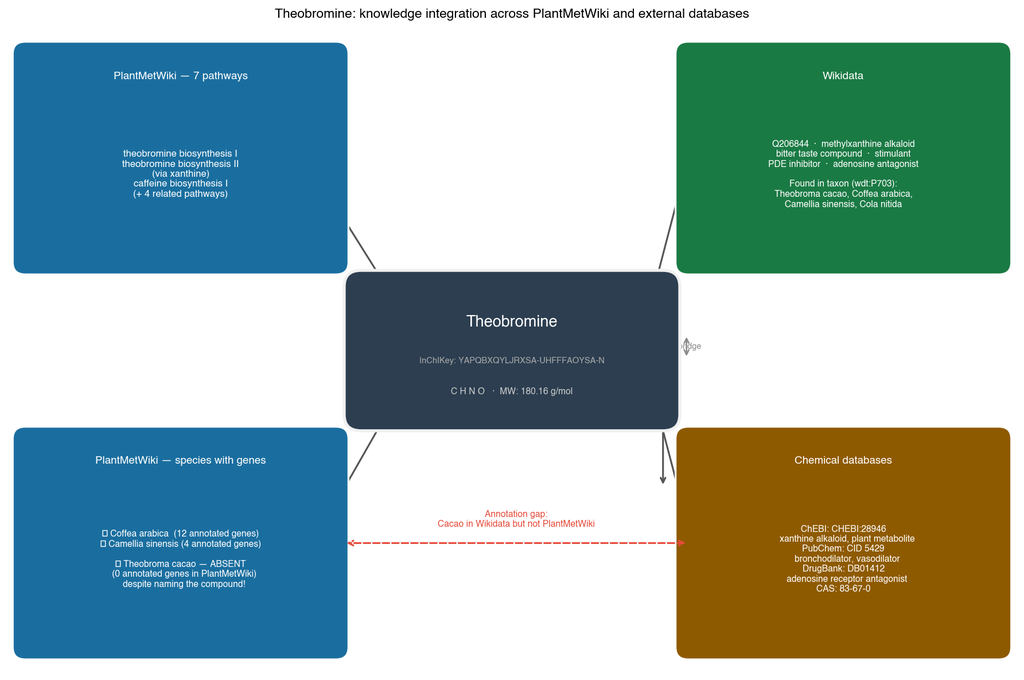

```
Saved: theobromine_knowledge_hub
```

```python
# ─────────────────────────────────────────────────────────────────────────────
# Figure A: Knowledge integration hub for theobromine
# ─────────────────────────────────────────────────────────────────────────────
import matplotlib.patches as mpatches
import matplotlib.patheffects as pe

fig, ax = plt.subplots(figsize=(12, 8))
ax.set_xlim(0, 12); ax.set_ylim(0, 8); ax.axis('off')

def rounded_box(ax, x, y, w, h, color, text, title=None, fontsize=8):
    rect = mpatches.FancyBboxPatch((x, y), w, h,
        boxstyle="round,pad=0.15", facecolor=color, edgecolor='white', linewidth=1.5, zorder=2)
    ax.add_patch(rect)
    if title:
        ax.text(x + w/2, y + h - 0.22, title,
                ha='center', va='top', fontsize=9, fontweight='bold', color='white', zorder=3)
    ax.text(x + w/2, y + h/2 - (0.2 if title else 0), text,
            ha='center', va='center', fontsize=fontsize, color='white',
            multialignment='center', zorder=3)

def arrow(ax, x1, y1, x2, y2, color='#555'):
    ax.annotate('', xy=(x2,y2), xytext=(x1,y1),
                arrowprops=dict(arrowstyle='->', color=color, lw=1.5),
                zorder=1)

# ── Center: theobromine ──────────────────────────────────────────────────────
cx, cy, cw, ch = 4.2, 3.2, 3.6, 1.6
rect_c = mpatches.FancyBboxPatch((cx, cy), cw, ch,
    boxstyle="round,pad=0.2", facecolor='#2c3e50', edgecolor='#f0f0f0', linewidth=2.5, zorder=4)
ax.add_patch(rect_c)
ax.text(cx+cw/2, cy+ch*0.72, 'Theobromine', ha='center', va='center',
        fontsize=13, fontweight='bold', color='white', zorder=5)
ax.text(cx+cw/2, cy+ch*0.42, 'InChIKey: YAPQBXQYLJRXSA-UHFFFAOYSA-N',
        ha='center', va='center', fontsize=7, color='#aaa', zorder=5, style='italic')
ax.text(cx+cw/2, cy+ch*0.18, 'C₇H₈N₄O₂  ·  MW: 180.16 g/mol',
        ha='center', va='center', fontsize=7.5, color='#ccc', zorder=5)

# ── Top-left: PlantMetWiki pathways ─────────────────────────────────────────
rounded_box(ax, 0.2, 5.1, 3.7, 2.6, '#1a6e9f',
    'theobromine biosynthesis I\ntheobromine biosynthesis II\n(via xanthine)\ncaffeine biosynthesis I\n(+ 4 related pathways)',
    title='PlantMetWiki — 7 pathways', fontsize=8)
arrow(ax, 3.9, 5.8, 4.5, 4.8)

# ── Bottom-left: Species (gap!) ──────────────────────────────────────────────
rounded_box(ax, 0.2, 0.3, 3.7, 2.6, '#1a6e9f',
    '✓ Coffea arabica  (12 annotated genes)\n✓ Camellia sinensis (4 annotated genes)\n\n✗ Theobroma cacao — ABSENT\n   (0 annotated genes in PlantMetWiki)\n   despite naming the compound!',
    title='PlantMetWiki — species with genes', fontsize=7.5)
arrow(ax, 3.9, 2.1, 4.5, 3.2)

# ── Top-right: Wikidata ──────────────────────────────────────────────────────
rounded_box(ax, 8.1, 5.1, 3.7, 2.6, '#1a7a44',
    'Q206844  ·  methylxanthine alkaloid\nbitter taste compound  ·  stimulant\nPDE inhibitor  ·  adenosine antagonist\n\nFound in taxon (wdt:P703):\nTheobroma cacao, Coffea arabica,\nCamellia sinensis, Cola nitida',
    title='Wikidata', fontsize=7.5)
arrow(ax, 7.8, 4.8, 7.6, 4.8)  # from center to wikidata

# ── Bottom-right: Other DBs ──────────────────────────────────────────────────
rounded_box(ax, 8.1, 0.3, 3.7, 2.6, '#8e5a00',
    'ChEBI: CHEBI:28946\n   xanthine alkaloid, plant metabolite\nPubChem: CID 5429\n   bronchodilator, vasodilator\nDrugBank: DB01412\n   adenosine receptor antagonist\nCAS: 83-67-0',
    title='Chemical databases', fontsize=7.5)
arrow(ax, 7.8, 3.5, 7.8, 2.3)

# ── Connect right panels ─────────────────────────────────────────────────────
arrow(ax, 7.7, 4.8, 8.1, 6.4)   # center → wikidata
arrow(ax, 7.7, 3.4, 8.1, 1.8)   # center → chem DBs

# ── InChIKey bridge label ────────────────────────────────────────────────────
ax.text(7.9, 4.05, 'InChIKey bridge', ha='center', va='center', fontsize=7,
        color='#888', style='italic')
ax.annotate('', xy=(8.08, 4.2), xytext=(8.08, 3.9),
            arrowprops=dict(arrowstyle='<->', color='#888', lw=1.2))

# ── Gap annotation ───────────────────────────────────────────────────────────
ax.annotate('', xy=(4.0, 1.6), xytext=(8.1, 1.6),
            arrowprops=dict(arrowstyle='<->', color='#e74c3c', lw=1.5,
                           linestyle='dashed'))
ax.text(6.05, 1.78, 'Annotation gap:\nCacao in Wikidata but not PlantMetWiki',
        ha='center', va='bottom', fontsize=7.5, color='#e74c3c', fontweight='bold')

ax.set_title('Theobromine: knowledge integration across PlantMetWiki and external databases',
             fontsize=11, fontweight='bold', pad=10)
plt.tight_layout()
plt.savefig('figures/output/figures/theobromine_knowledge_hub.pdf', bbox_inches='tight')
plt.savefig('figures/output/figures/theobromine_knowledge_hub.svg', bbox_inches='tight')
plt.show()
print("Saved: theobromine_knowledge_hub")
```

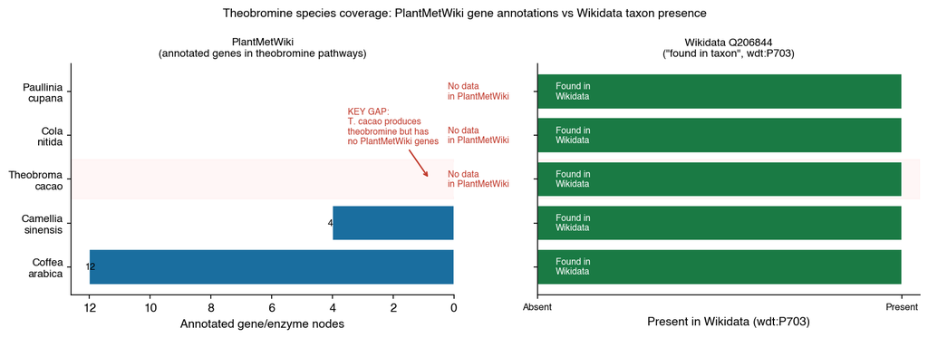

```
Saved: theobromine_species_gap
```

```python
# ─────────────────────────────────────────────────────────────────────────────
# Figure B: Species gap — PlantMetWiki vs Wikidata "found in taxon"
# ─────────────────────────────────────────────────────────────────────────────

# PlantMetWiki: species with annotated genes in theobromine pathways
pmw_species = {
    'Coffea arabica':      12,   # in PlantMetWiki theobromine pathways
    'Camellia sinensis':    4,
    'Theobroma cacao':      0,   # the gap!
    'Cola nitida':          0,
    'Paullinia cupana':     0,
}

# Wikidata "found in taxon" (wdt:P703) for theobromine Q206844
# Pre-verified via QLever; shows biological presence regardless of PlantCyc curation
wd_presence = {
    'Coffea arabica':      True,
    'Camellia sinensis':   True,
    'Theobroma cacao':     True,  # confirmed Q288051/theobromine wdt:P703
    'Cola nitida':         True,
    'Paullinia cupana':    True,  # guarana
}

species = list(pmw_species.keys())
pmw_vals = [pmw_species[s] for s in species]
wd_vals  = [1 if wd_presence.get(s, False) else 0 for s in species]  # 1=present, 0=absent

fig, (ax1, ax2) = plt.subplots(1, 2, figsize=(11, 4), sharey=True)
y = np.arange(len(species))
COLORS_PMW = ['#1a6e9f' if v > 0 else '#ffcccc' for v in pmw_vals]
COLORS_WD  = ['#1a7a44' if v > 0 else '#eee' for v in wd_vals]

# Left panel: PlantMetWiki gene counts
bars = ax1.barh(y, pmw_vals, color=COLORS_PMW, edgecolor='white', linewidth=0.8)
ax1.set_yticks(y)
ax1.set_yticklabels([s.replace(' ', '\n') for s in species], fontsize=9)
ax1.set_xlabel('Annotated gene/enzyme nodes')
ax1.set_title('PlantMetWiki\n(annotated genes in theobromine pathways)', fontsize=9)
ax1.invert_xaxis()
for bar, v, s in zip(bars, pmw_vals, species):
    if v == 0:
        ax1.text(0.2, bar.get_y()+bar.get_height()/2,
                 'No data\nin PlantMetWiki', va='center', fontsize=7.5,
                 color='#c0392b', style='italic')
    else:
        ax1.text(v + 0.15, bar.get_y()+bar.get_height()/2, f'{v}', va='center', fontsize=8)
ax1.spines[['top','right']].set_visible(False)

# Right panel: Wikidata "found in taxon"
bars2 = ax2.barh(y, wd_vals, color=COLORS_WD, edgecolor='white', linewidth=0.8)
ax2.set_xlabel('Present in Wikidata (wdt:P703)')
ax2.set_title('Wikidata Q206844\n("found in taxon", wdt:P703)', fontsize=9)
ax2.set_xticks([0, 1])
ax2.set_xticklabels(['Absent', 'Present'], fontsize=8)
for bar, v in zip(bars2, wd_vals):
    label = 'Found in\nWikidata' if v else 'Absent'
    ax2.text(0.05, bar.get_y()+bar.get_height()/2, label, va='center', fontsize=7.5,
             color='white' if v else '#888')
ax2.spines[['top','right']].set_visible(False)

# Highlight the gap species
for i, s in enumerate(species):
    if s == 'Theobroma cacao':
        for ax in [ax1, ax2]:
            ax.axhspan(i-0.45, i+0.45, color='#ffeeee', alpha=0.5, zorder=0)

# Annotation
ax1.annotate('KEY GAP:\nT. cacao produces\ntheobromine but has\nno PlantMetWiki genes',
             xy=(0.8, 2), xytext=(3.5, 2.8),
             fontsize=7.5, color='#c0392b', fontweight='bold',
             arrowprops=dict(arrowstyle='->', color='#c0392b', lw=1.2))

fig.suptitle('Theobromine species coverage: PlantMetWiki gene annotations vs Wikidata taxon presence',
             fontsize=10, fontweight='bold')
plt.tight_layout()
plt.savefig('figures/output/figures/theobromine_species_gap.pdf', bbox_inches='tight')
plt.savefig('figures/output/figures/theobromine_species_gap.svg', bbox_inches='tight')
plt.show()
print("Saved: theobromine_species_gap")
```

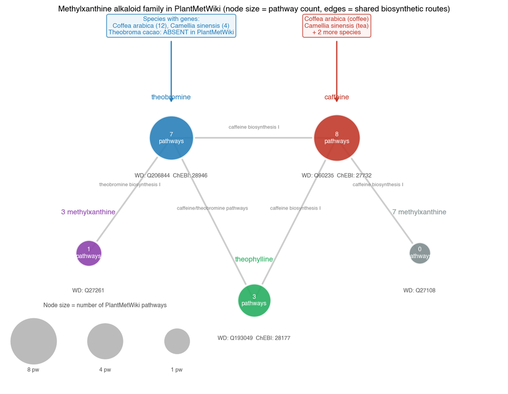

```
Saved: methylxanthine_family_network
```

```python
# ─────────────────────────────────────────────────────────────────────────────
# Figure C: Methylxanthine metabolic family network
# ─────────────────────────────────────────────────────────────────────────────
import matplotlib.patheffects as pe

# Methylxanthine family data (from local Virtuoso query)
XANTHINES = {
    'caffeine':         {'n_pw': 8,  'wd': 'Q60235',  'chebi': '27732', 'color': '#c0392b', 'x': 6.0,  'y': 5.2},
    'theobromine':      {'n_pw': 7,  'wd': 'Q206844', 'chebi': '28946', 'color': '#2980b9', 'x': 3.0,  'y': 5.2},
    'theophylline':     {'n_pw': 3,  'wd': 'Q193049', 'chebi': '28177', 'color': '#27ae60', 'x': 4.5,  'y': 2.8},
    '3-methylxanthine': {'n_pw': 1,  'wd': 'Q27261',  'chebi': '',      'color': '#8e44ad', 'x': 1.5,  'y': 3.5},
    '7-methylxanthine': {'n_pw': 0,  'wd': 'Q27108',  'chebi': '',      'color': '#7f8c8d', 'x': 7.5,  'y': 3.5},
}
# Shared pathway edges (compounds that co-occur in the same PC* pathway)
EDGES = [
    ('caffeine','theobromine',    'caffeine biosynthesis I, II'),
    ('caffeine','theophylline',   'caffeine biosynthesis I'),
    ('theobromine','theophylline','caffeine/theobromine pathways'),
    ('theobromine','3-methylxanthine','theobromine biosynthesis I'),
    ('caffeine','7-methylxanthine','caffeine biosynthesis I'),
]

fig, ax = plt.subplots(figsize=(9, 7))
ax.set_xlim(0, 9); ax.set_ylim(1.5, 7); ax.axis('off')

# Draw edges first
for src, tgt, label in EDGES:
    xs, ys = XANTHINES[src]['x'], XANTHINES[src]['y']
    xt, yt = XANTHINES[tgt]['x'], XANTHINES[tgt]['y']
    ax.plot([xs, xt], [ys, yt], '-', color='#ccc', lw=2, zorder=1)
    # Edge label at midpoint
    mx, my = (xs+xt)/2, (ys+yt)/2
    ax.text(mx, my+0.12, label.split(',')[0], ha='center', va='bottom',
            fontsize=6.5, color='#888', style='italic')

# Draw nodes
for name, d in XANTHINES.items():
    size = 800 + d['n_pw'] * 350
    ax.scatter(d['x'], d['y'], s=size, c=d['color'],
               zorder=3, edgecolors='white', linewidths=2.5, alpha=0.9)
    # Name label above
    ax.text(d['x'], d['y'] + 0.55, name.replace('-',' '),
            ha='center', va='bottom', fontsize=9, fontweight='bold', zorder=4,
            color=d['color'])
    # ID labels below
    ids = f"WD: {d['wd']}"
    if d['chebi']:
        ids += f"  ChEBI: {d['chebi']}"
    ax.text(d['x'], d['y'] - 0.52, ids,
            ha='center', va='top', fontsize=7, color='#555', zorder=4)
    # Pathway count inside node
    ax.text(d['x'], d['y'], f"{d['n_pw']}\npathways",
            ha='center', va='center', fontsize=7.5, color='white',
            fontweight='bold', zorder=5, multialignment='center')

# Species annotation for theobromine/caffeine
ax.text(3.0, 7.0,
        'Species with genes:\nCoffea arabica (12), Camellia sinensis (4)\nTheobroma cacao: ABSENT in PlantMetWiki',
        ha='center', va='top', fontsize=8, color='#2980b9',
        bbox=dict(boxstyle='round,pad=0.3', facecolor='#eaf4fb', edgecolor='#2980b9', alpha=0.8))
ax.annotate('', xy=(3.0, 5.7), xytext=(3.0, 6.65),
            arrowprops=dict(arrowstyle='->', color='#2980b9', lw=1.5))

ax.text(6.0, 7.0,
        'Coffea arabica (coffee)\nCamellia sinensis (tea)\n+ 2 more species',
        ha='center', va='top', fontsize=8, color='#c0392b',
        bbox=dict(boxstyle='round,pad=0.3', facecolor='#fdf2f2', edgecolor='#c0392b', alpha=0.8))
ax.annotate('', xy=(6.0, 5.7), xytext=(6.0, 6.65),
            arrowprops=dict(arrowstyle='->', color='#c0392b', lw=1.5))

# Legend for node size
for n_pw, lx, ly in [(8, 0.5, 2.2), (4, 1.8, 2.2), (1, 3.1, 2.2)]:
    ax.scatter(lx, ly, s=800+n_pw*350, c='#bbb', edgecolors='white', linewidths=1.5, zorder=3)
    ax.text(lx, ly-0.45, f'{n_pw} pw', ha='center', fontsize=7, color='#555')
ax.text(1.8, 2.7, 'Node size = number of PlantMetWiki pathways',
        ha='center', fontsize=7.5, color='#555', style='italic')

ax.set_title('Methylxanthine alkaloid family in PlantMetWiki (node size = pathway count, edges = shared biosynthetic routes)',
             fontsize=10, fontweight='bold')
plt.tight_layout()
plt.savefig('figures/output/figures/methylxanthine_family_network.pdf', bbox_inches='tight')
plt.savefig('figures/output/figures/methylxanthine_family_network.svg', bbox_inches='tight')
plt.show()
print("Saved: methylxanthine_family_network")
```

> **Figure interpretation notes:**

> **Figure A (hub diagram):** Shows theobromine as the integration point between PlantMetWiki (pathway and gene data, left) and external knowledge databases (Wikidata, ChEBI, PubChem, DrugBank, right). The dashed red arrow highlights the key annotation gap: Wikidata knows theobromine is found in *Theobroma cacao* (chocolate), but PlantMetWiki has no *T. cacao* genes in its theobromine pathway — an inference target revealed only by combining the two resources.

> **Figure B (species gap):** Directly visualises the gap. All five species known to produce theobromine (Wikidata wdt:P703) are shown alongside their PlantMetWiki gene annotation depth. Only coffee and tea have annotated genes; cacao, kola, and guarana are entirely absent — highlighting which species' pathways most need experimental follow-up or annotation transfer.

## Summary — key findings for the results section

[output not shown]

### Case study takeaways

**Theobromine** (Wikidata Q206844, CAS 83-67-0):